# Differential Binding Analysis

- Since the diffBind R-package didnt work due to missing qualitative bam files, we followed the methods of Nativio et al.
- We are comparing the signal values between the groups for each peak/region.
- Those signals are already normalized by RPKM (reads per kilobase millions)
- We used a Wilcoxon Rank sum test for the pairwise comparison and for a further validation ANOVA for multiple comparison.
- The following script is repeated for each histone modificaiton data set, explainatory we are using the data from the H3K9ac modification

# Data import

In all next steps, all the info is going to be stored in the dataframe “df”

```r
df <- read.table("~/DataScienceProject/ChIP-seq/DiffBindanalysis/DiffBind_matrices/DiffBind_mat_H3K9ac.txt")
AD_index <- c(22:30)
old_index <- c(12:21)
young_index <- c(4:11)

colnames(df)[32] <- "distance.to.TSS"
colnames(df)[34] <- "gene.name"
colnames(df)[33] <- "region"
```

# Wilcoxon rank sum test

- we followed the instruction of Nativio et al., which did not included any p-value adjustment
- we did a p-value adjustment. However,this leads to 0 significant peaks. So we continued with the not corrected p-values.
- we tested AD vs old and old vs young

```r
execute_wilcox_test <- function(df, name, index1,index2){
  name.pv <- paste(name, "pval", sep=".")
  name.fc <- paste(name, "log2FC", sep=".")
  pvals <- c()
  foldchanges<- c()
  for (i in 1: nrow(df)){
    grp2 <- as.numeric(df[i, index2])
    grp1<- as.numeric( df[i, index1])
    fc<- (mean(grp2)/mean(grp1))
    log2FC<- log2(fc)
    p<- wilcox.test(grp1, grp2)$p.value
    pvals[i] <- p
    foldchanges[i] <- log2FC

  }

  df[, name.pv] <- pvals
  df[, name.fc ]<- foldchanges


  if (name =="ADO"){
    df<- df %>%
      mutate(ADO.status = case_when(ADO.log2FC > 0 & ADO.pval < 0.05 ~ "gain",
                                     ADO.log2FC < 0 & ADO.pval < 0.05 ~ "loss",
                                     TRUE ~ "not significant"))
    print(table(df$ADO.status))

  }
  else{
    df<- df %>%
      mutate(OY.status = case_when(OY.log2FC > 0 & OY.pval < 0.05 ~ "gain",
                                     OY.log2FC < 0 & OY.pval < 0.05 ~ "loss",

                                     TRUE ~ "not significant"))
    print(table(df$OY.status))

  }

  ## p-value adjustment , using Benjamini-Hochberg correction
  adj.pval <- p.adjust(pvals, "BH")
  print(mean(adj.pval < 0.05))

  return(df)
}


df <- execute_wilcox_test(df, "ADO", old_index, AD_index)
```

```
           gain            loss not significant
            391              45           14266
[1] 0
```

```r
df <- execute_wilcox_test(df, "OY", young_index, old_index)
```

```
           gain            loss not significant
             41             598           14063
[1] 0
```

# Visualization

1. Volcano plot
- visualizing the distribution of the log2FC vs p-values,
- for H3K27ac and H3K9ac more gains than losses, H3K122ac the other way around

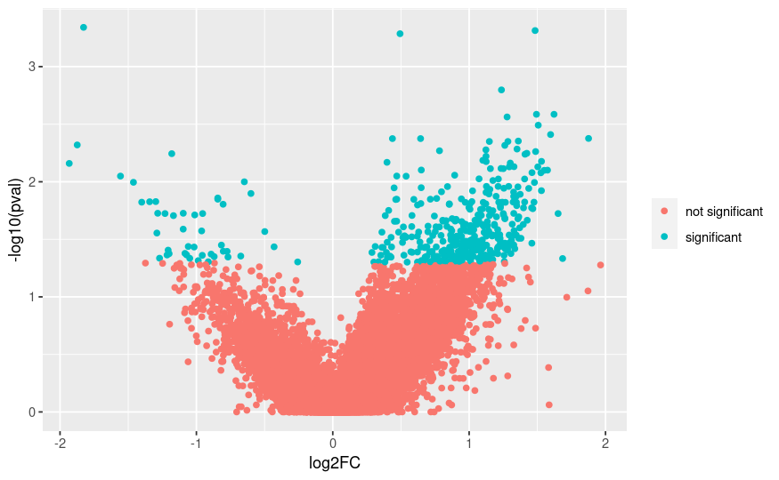

```r
create_volcanoplot <- function(df, name){
  name.pval <- paste(name, "pval", sep=".")
  name.fc <- paste(name, "log2FC", sep=".")
  data <-df[, c(name.pval, name.fc)]
  colnames(data)<- c("pval", "log2FC")
  data <- data %>%
      mutate(status2 = case_when( pval < 0.05 ~ "significant",

                                  TRUE ~ "not significant"))

  plot <- ggplot(data, aes(y= - log10(pval), x=log2FC, color=status2)) + geom_point()+ labs(colour=NULL)
  return (plot)

}

create_volcanoplot(df, "ADO")
```

2. Log2 FC distribution
- divided into not significant regions and significant ones
- to have better look on log2 FC without p-vals, non significant ones are roughly normally distributed

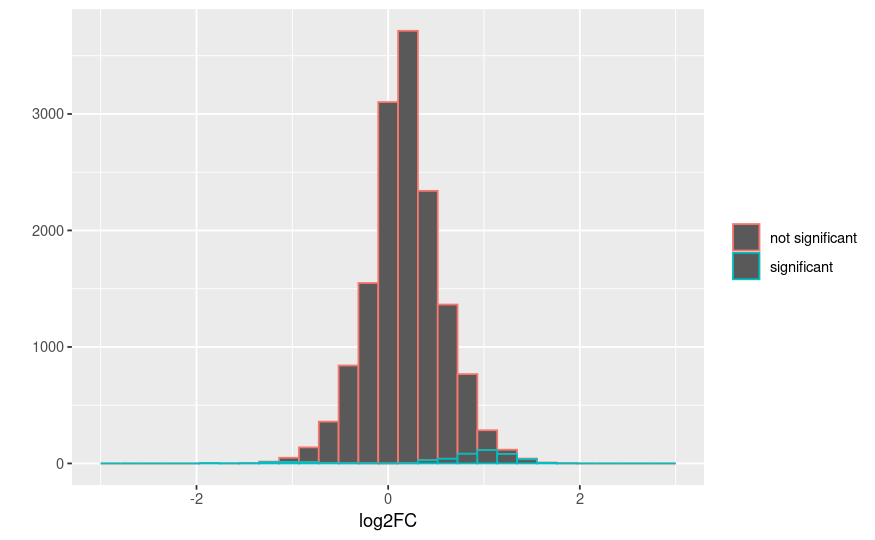

```r
create_FC_dist <- function(df, name, type="density"){
  name.pval <- paste(name, "pval", sep=".")
  name.fc <- paste(name, "log2FC", sep=".")
  data <-df[, c(name.pval, name.fc)]
  colnames(data)<- c("pval", "log2FC")
  data <- data %>%
    mutate(status2 = case_when( pval < 0.05 ~ "significant",

                                TRUE ~ "not significant"))

  if (type == "density"){
    return( ggplot(data, aes(x=log2FC, color=status2)) + geom_density() + labs(color=NULL))
  }
  else {
    return(ggplot(data, aes(x=log2FC, color=status2)) +   geom_histogram() + labs(color=NULL))
  }

}

create_FC_dist(df, "ADO", "hist") + xlim(-3,3) + ylab("")
```

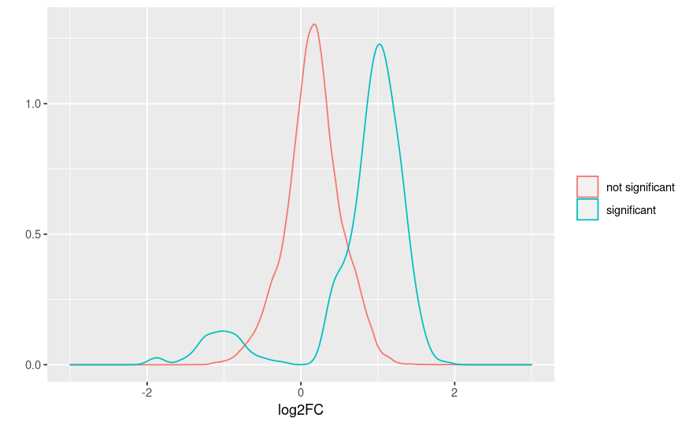

```r
create_FC_dist(df, "ADO") + xlim(-3,3) + ylab("")
```

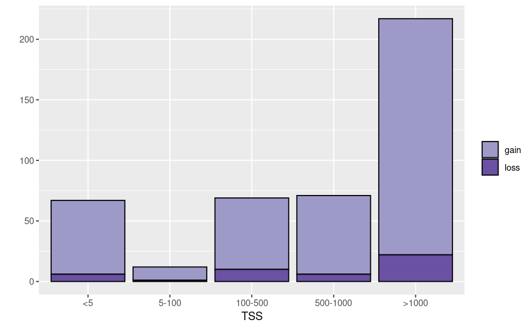

```r
create_barchart_TSS <- function(df, name){
  name.status <- paste(name, "status", sep=".")
  data <-df[, c(name.status, "distance.to.TSS")]
  colnames(data)<- c("status", "distance.to.TSS")
  data<- data %>%
    mutate(TSS = case_when( distance.to.TSS <=5 ~ "<5",
                            distance.to.TSS > 5  & distance.to.TSS <= 100 ~ "5-100",
                            distance.to.TSS > 100 & distance.to.TSS <= 500 ~ "100-500",
                            distance.to.TSS > 500 & distance.to.TSS <= 1000 ~ "500-1000",
                            distance.to.TSS > 1000 ~ ">1000"

    ) )
  data$TSS <- factor(data$TSS, levels = c("<5", "5-100", "100-500", "500-1000", ">1000"))

  gains<-filter(data, status!="not significant" ) %>% group_by(TSS) %>% summarise(count=sum(status=="gain")) %>% cbind(status=rep("gain", 5))
  losses<- filter(data, status!="not significant" ) %>% group_by(TSS) %>% summarise(count=sum(status=="loss")) %>% cbind(status=rep("loss", 5))
  plot.df <- rbind(gains,losses)

  plot <- ggplot(plot.df, aes(x = TSS, y=count ,fill = status)) +
    geom_bar(stat="identity", color = "black") +
    scale_fill_manual(values = c( "#9E9AC8", "#6A51A3")) +
    guides(fill = guide_legend(title = "")) +
    ylab("")

  return(plot)

}

create_barchart_TSS(df, "ADO")
```

```r
NA
NA
```

# ANOVA

- to validate result of Wilcoxon rank sum test
- ANOVA assumes normality and equal sample variances
- we are checking both assumption with shapiro test and levene test
- for a big number of peaks, the shapiro gets rejected, p-value < 0.05
- that’s why the result of the ANOVA test should not be taken to “serious”
- but that’s the way Nativio et al. did their analysis.

```r
library(car)
execute.ANOVA.test <- function(df, idx1,idx2,idx3){

  shapiro.res<- c()
  levene.res<- c()
  anova.res <- c()
  for (i in 1:nrow(df)){
    grp1 <- data.frame(count=as.numeric(df[i, idx1]), group=rep("AD", length(idx1)))
    grp2 <- data.frame(count=as.numeric(df[i, idx2]), group=rep("old", length(idx2)))
    grp3 <- data.frame(count=as.numeric(df[i, idx3]), group=rep("young", length(idx3)))

    together<- rbind(grp1,grp2,grp3)

    res_aov <- aov(count ~ group, data=together)

    anova.res[i] <- unlist(summary(res_aov))[9]
    shapiro.res[i]<- shapiro.test(res_aov$residuals)$p.value
    levene.res[i] <- leveneTest(count ~group, data=together)$Pr[1]
  }

  results <- data.frame( anova.pval = anova.res, shapiro.pval = shapiro.res, levene.pval = levene.res )

  return(results)
}

anova.df <- execute.ANOVA.test(df, young_index, old_index, AD_index)
```

- intersection of anova and wilcoxon tests
- only keeping peaks that are signifcant in both tests
- the disease specific significant regions are saved in the folder “disease_spec_enriched_peaks”

```r
df <- cbind(df, anova.pval=anova.df$anova.pval)

disease.specific<- filter(df, ADO.pval <0.05 & anova.pval <0.05)
age.regulated <- filter(df,OY.pval <0.05 & ADO.pval >= 0.05 & anova.pval <0.05 )
age.dysregulated <- filter(df, (ADO.pval <0.05 | OY.pval <0.05) & anova.pval <0.05)

nrow(disease.specific)
```

```
[1] 248
```

# boxplot

- have a look on the overall distribution of the signals for the significant peaks between the groups
- as expected, AD has a lower median for losses and a higher median for gains compared to the old and young group

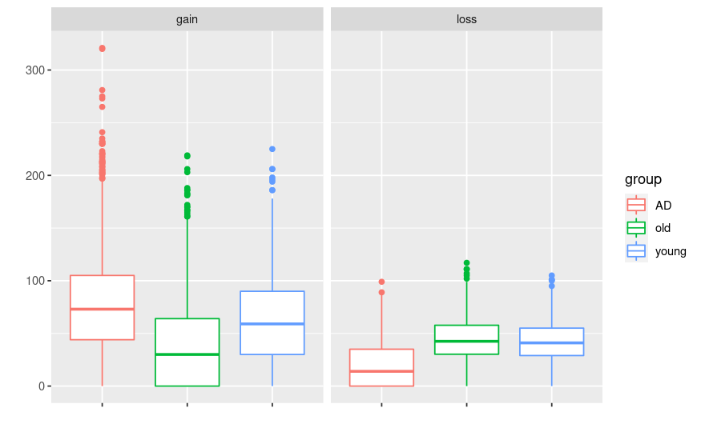

```r
create.boxplot <- function(data, name ){
  name.status <- paste(name, "status", sep=".")

  gain.df<- data[which(data[, name.status] == "gain"),]
  loss.df<- data[which(data[, name.status] == "loss"),]

  loss.all.young <-unlist(loss.df[, young_index])
  loss.all.old <- unlist(loss.df[, old_index])
  loss.all.AD <- unlist(loss.df[, AD_index])
  loss.labels<- c( rep("young", length(loss.all.young)),
                   rep("old", length(loss.all.old)),
                   rep("AD", length(loss.all.AD))

  )

  all.young <-unlist(gain.df[, young_index])
  all.old <- unlist(gain.df[, old_index])
  all.AD <- unlist(gain.df[, AD_index])
  labels<- c( rep("young", length(all.young)),
              rep("old", length(all.old)),
              rep("AD", length(all.AD))

  )

  gain.length <- length(all.young)+ length(all.old)+ length(all.AD)
  loss.length <- length(loss.all.young)+ length(loss.all.old)+ length(loss.all.AD)

  boxplot.df <- data.frame(counts= c(all.young, all.old, all.AD, loss.all.young, loss.all.old, loss.all.AD),
                           group=c(labels, loss.labels),
                           status= c(rep("gain", gain.length ),rep("loss", loss.length ) ))


  plot<- ggplot(boxplot.df, aes(x=group, y=counts, color=group)) +
    geom_boxplot()  +
    theme( axis.text.x = element_blank())+
    xlab("")+
    ylab("")+
    facet_grid(~status)

  return(plot)


}


create.boxplot(disease.specific, "ADO")
```

# CHip-Seq and RNA-seq

- lastly, we compare the peaks and their associated genes with the DEG genes of the RNA-seq
- we visualize the overlaps with the help of venn diagrams
- first step: reading in the significant DEG and determine the path to save the result

```r
library(ggvenn)
down.path <- "~/DataScienceProject/RNA-seq/UpDownreg_genes/downregulationgenes.txt"
up.path <- "~/DataScienceProject/RNA-seq/UpDownreg_genes/upregulatedgenes.txt"
save.path <- "~/intersection_H3K9ac.csv"
```

- creating intersections, venn diagrams and saving everything in a table
- we expect intersections between up DEGs and gains, since the histone acetylation are enhancing transcription
- we expect intersections between down DEGs and losses, since with lossing acetylation the transcription is not activated.
- however, we oberserved also other intersections, which makes biologically ( at first glance ) not a lot of sense,
- furthermore, a rather smaller overlap between the two omic data sets can be observed.

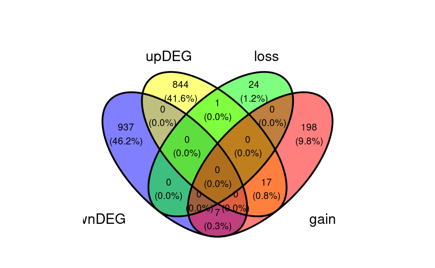

```r
comapre_chip_rnaseq  <- function(data, up.path, down.path, save.path){

  down_DEG <- read.table(down.path)
  up_DEG <- read.table(up.path)

  down.inter.genes<- intersect(down_DEG$V1, disease.specific$gene.name)
  up.inter.genes<- intersect(up_DEG$V1, disease.specific$gene.name)

  gene.label <- c(rep("down", length(down.inter.genes)), rep("up", length(up.inter.genes)))

  down.status<- filter(filter(disease.specific, gene.name %in% down.inter.genes) , !duplicated(gene.name))$ADO.status
  up.status<- filter(filter(disease.specific, gene.name %in% up.inter.genes), !duplicated(gene.name))$ADO.status

  status.label <- c(down.status, up.status)

  gain.gene.names <- filter(filter(disease.specific, ADO.status=="gain") , !duplicated(gene.name))$gene.name
  loss.gene.names <- filter(filter(disease.specific, ADO.status=="loss") , !duplicated(gene.name))$gene.name



  intersection.df <- data.frame(gene.name = c(down.inter.genes, up.inter.genes),
                                DEG.status= gene.label,
                                chip.status = status.label

  )

  #write.csv(intersection.df, file=save.path, row.names = F)


  plot<- ggvenn(list(downDEG=down_DEG$V1 , upDEG=up_DEG$V1 ,loss=loss.gene.names,gain=gain.gene.names  ))

  return(plot)
}

comapre_chip_rnaseq(disease.specific, up.path, down.path , save.path)
```